# DSC540 Project 3

DePaul University  
Ilyas Ustun, PhD  
Chicago, IL

## Rules

- Write your code under the corresponding questions. You are encouraged to use more than one cell.
- Provide explanation in a separate Markdown formatted cell.
- You can change the cell type by:
  - Click on the outer area of the cell type you want to change,
  - Go to the top, and select either Code or Markdown from the dropdown menu.
- Be concise in your explanations and conclusions.
- Write clear code and provide explanation to functions you create by using `#` comment sign.
- Try to answer the questions by yourself. Use documentation from pandas, sklearn and similar libraries to solve the problem.
- If you are stuck you can use different resources. Do not find an identical project and copy paste the solutions.
- Write your name at the beginning of the jupyter notebook.

Important:

- **Do NOT share the solutions with other people.**
- **Do NOT share the solutions on the internet including but not limited to Github and other platforms.**
- Sign the Honor Pledge below indicating that you have agreed to these rules listed here, and any other ethical and honor rules as required by the university.
- **Deliverables:**
  1. The Python Jupyter notebook file named properly with your name. Example: dsc540_project1_john_doe.ipynb
  2. The HTML output of this code notebook names the same way. Example: dsc540_project1_john_doe.html
     - File -> Download as -> HTML

**DO NOT zip the files.**

Good Luck!

### Nihar Muniraju

**Honor Pledge:**  
I pledge on my honor that I, **Nihar Muniraju**, have followed the rules listed above, that I have not given or received any unauthorized assistance on this assignment.

## Project Description

In this project we will be analyzing CO and NOX gas emissions from a power plant. The variables, their meanings and some statistics are given in the table below.

[figure not shown]

## Import Libraries

**Import the usual libraries for pandas and plotting, and sklearn.**

```python
import pandas as pd
import numpy as np
import matplotlib.pyplot as plt
import seaborn as sns

from sklearn import metrics
```

```python
import sklearn
sklearn.__version__
```

```
'1.2.2'
```

```python
pd.set_option('display.max_columns', 100)
RANDOM_STATE = 0
```

### These are the packages I used

```python
# Your package imports here
```

```python
from sklearn.metrics import r2_score, mean_squared_error
from sklearn.model_selection import GridSearchCV
from sklearn.linear_model import LinearRegression
from sklearn.ensemble import RandomForestRegressor
from sklearn.preprocessing import StandardScaler
from sklearn.metrics import accuracy_score
from sklearn.model_selection import train_test_split
from sklearn.svm import SVR
from sklearn.preprocessing import Binarizer
from sklearn.metrics import confusion_matrix, recall_score, precision_score, f1_score, balanced_accuracy_score, classification_report
from sklearn.ensemble import GradientBoostingClassifier
from sklearn.feature_selection import SelectFromModel
from sklearn.decomposition import PCA
from sklearn.ensemble import RandomForestClassifier
from sklearn.preprocessing import PolynomialFeatures
import warnings
warnings.filterwarnings("ignore", category=FutureWarning)
```

> NOTE: For the Kernel RBF SVM hyper parameter tuning use these parameters in the questions:

```
    'C': [1, 10, 100, 1000]
    'gamma': [0.001, 0.01, 0.1, 1]
```

## Q1 [10]

- Read in the dataset
- How many rows and variables are there?

#### Get the Data

**Use pandas to read in the datasets as a dataframe.**

```python
df = pd.read_csv('gas_emissions.csv')
```

```python
df
```

|  | AT | AP | AH | AFDP | GTEP | TIT | TAT | TEY | CDP | CO | NOX |
| --- | --- | --- | --- | --- | --- | --- | --- | --- | --- | --- | --- |
| 0 | 1.95320 | 1020.1 | 84.985 | 2.5304 | 20.116 | 1048.7 | 544.92 | 116.27 | 10.799 | 7.4491 | 113.250 |
| 1 | 1.21910 | 1020.1 | 87.523 | 2.3937 | 18.584 | 1045.5 | 548.50 | 109.18 | 10.347 | 6.4684 | 112.020 |
| 2 | 0.94915 | 1022.2 | 78.335 | 2.7789 | 22.264 | 1068.8 | 549.95 | 125.88 | 11.256 | 3.6335 | 88.147 |
| 3 | 1.00750 | 1021.7 | 76.942 | 2.8170 | 23.358 | 1075.2 | 549.63 | 132.21 | 11.702 | 3.1972 | 87.078 |
| 4 | 1.28580 | 1021.6 | 76.732 | 2.8377 | 23.483 | 1076.2 | 549.68 | 133.58 | 11.737 | 2.3833 | 82.515 |
| ... | ... | ... | ... | ... | ... | ... | ... | ... | ... | ... | ... |
| 7379 | 3.62680 | 1028.5 | 93.200 | 3.1661 | 19.087 | 1037.0 | 541.59 | 109.08 | 10.411 | 10.9930 | 89.172 |
| 7380 | 4.16740 | 1028.6 | 94.036 | 3.1923 | 19.016 | 1037.6 | 542.28 | 108.79 | 10.344 | 11.1440 | 88.849 |
| 7381 | 5.48200 | 1028.5 | 95.219 | 3.3128 | 18.857 | 1038.0 | 543.48 | 107.81 | 10.462 | 11.4140 | 96.147 |
| 7382 | 5.88370 | 1028.7 | 94.200 | 3.9831 | 23.563 | 1076.9 | 550.11 | 131.41 | 11.771 | 3.3134 | 64.738 |
| 7383 | 6.03920 | 1028.8 | 94.547 | 3.8752 | 22.524 | 1067.9 | 548.23 | 125.41 | 11.462 | 11.9810 | 109.240 |

7384 rows × 11 columns

```python
df.shape
```

```
(7384, 11)
```

### There are 7384 rows and 11 columns

```python
df.info()
```

```
<class 'pandas.core.frame.DataFrame'>
RangeIndex: 7384 entries, 0 to 7383
Data columns (total 11 columns):
 #   Column  Non-Null Count  Dtype
---  ------  --------------  -----
 0   AT      7384 non-null   float64
 1   AP      7384 non-null   float64
 2   AH      7384 non-null   float64
 3   AFDP    7384 non-null   float64
 4   GTEP    7384 non-null   float64
 5   TIT     7384 non-null   float64
 6   TAT     7384 non-null   float64
 7   TEY     7384 non-null   float64
 8   CDP     7384 non-null   float64
 9   CO      7384 non-null   float64
 10  NOX     7384 non-null   float64
dtypes: float64(11)
memory usage: 634.7 KB
```

#### Is there any missing data?

```python
df.isna().sum()
```

```
AT      0
AP      0
AH      0
AFDP    0
GTEP    0
TIT     0
TAT     0
TEY     0
CDP     0
CO      0
NOX     0
dtype: int64
```

```python
df.isnull()
```

|  | AT | AP | AH | AFDP | GTEP | TIT | TAT | TEY | CDP | CO | NOX |
| --- | --- | --- | --- | --- | --- | --- | --- | --- | --- | --- | --- |
| 0 | False | False | False | False | False | False | False | False | False | False | False |
| 1 | False | False | False | False | False | False | False | False | False | False | False |
| 2 | False | False | False | False | False | False | False | False | False | False | False |
| 3 | False | False | False | False | False | False | False | False | False | False | False |
| 4 | False | False | False | False | False | False | False | False | False | False | False |
| ... | ... | ... | ... | ... | ... | ... | ... | ... | ... | ... | ... |
| 7379 | False | False | False | False | False | False | False | False | False | False | False |
| 7380 | False | False | False | False | False | False | False | False | False | False | False |
| 7381 | False | False | False | False | False | False | False | False | False | False | False |
| 7382 | False | False | False | False | False | False | False | False | False | False | False |
| 7383 | False | False | False | False | False | False | False | False | False | False | False |

7384 rows × 11 columns

### There is no missing data as the shape of the df is 7384*11 after searching for the data missing it shows the same dataframe

#### What is the average value of AP for those points who have CO levels above 3 $mg/m^3$?

```python
# lets create a mask for CO levels greater than 3 mg/m^3
co_mask = df['CO'] > 3

# we perform a subselection for all those points meeting the criteria specificied in the mask.
df_co_3 = df[co_mask]

# we find the average value of AP
df_co_3['AP'].mean()
```

```
1015.690017349063
```

#### Create a correlation map between the variables. Which variables have high correlation (> |0.9|)?

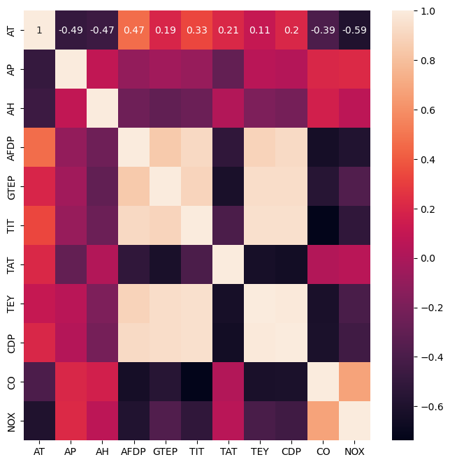

```python
matrix1 = df.corr()
matrix1
plt.figure(figsize = (8,8))
sns.heatmap(matrix1, annot=True)
```

```python
corr = matrix1.abs().unstack().sort_values(kind="quicksort", ascending=False)
corr = corr[corr > 0.9]
corr = corr[corr < 1]

print(corr)
```

```
CDP   TEY     0.991207
TEY   CDP     0.991207
TIT   TEY     0.951813
TEY   TIT     0.951813
TIT   CDP     0.951590
CDP   TIT     0.951590
GTEP  CDP     0.938142
CDP   GTEP    0.938142
GTEP  TEY     0.932337
TEY   GTEP    0.932337
CDP   AFDP    0.922991
AFDP  CDP     0.922991
TIT   AFDP    0.915128
AFDP  TIT     0.915128
dtype: float64
```

```python
corr
```

```
CDP   TEY     0.991207
TEY   CDP     0.991207
TIT   TEY     0.951813
TEY   TIT     0.951813
TIT   CDP     0.951590
CDP   TIT     0.951590
GTEP  CDP     0.938142
CDP   GTEP    0.938142
GTEP  TEY     0.932337
TEY   GTEP    0.932337
CDP   AFDP    0.922991
AFDP  CDP     0.922991
TIT   AFDP    0.915128
AFDP  TIT     0.915128
dtype: float64
```

#### Create a scatter plot of 'TEY' vs 'CDP'

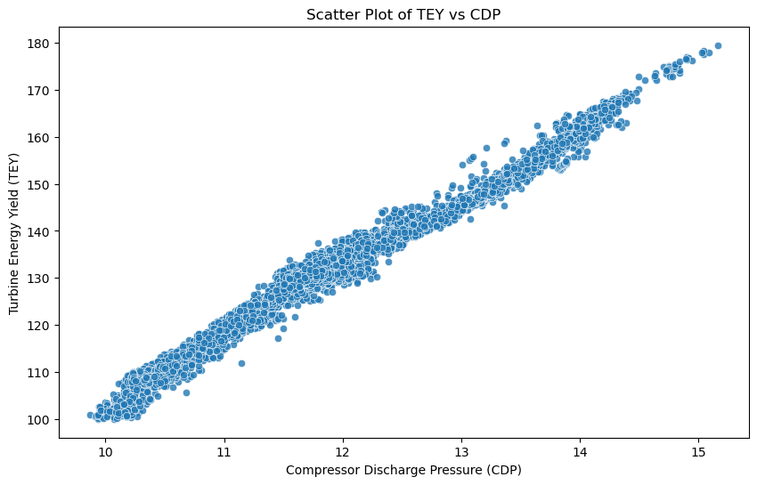

```python
plt.figure(figsize=(10, 6))
sns.scatterplot(x=df['CDP'], y=df['TEY'], alpha=0.8)
plt.title('Scatter Plot of TEY vs CDP')
plt.xlabel('Compressor Discharge Pressure (CDP)')
plt.ylabel('Turbine Energy Yield (TEY)')
plt.show();
```

#### Create histograms for CO and NOX.

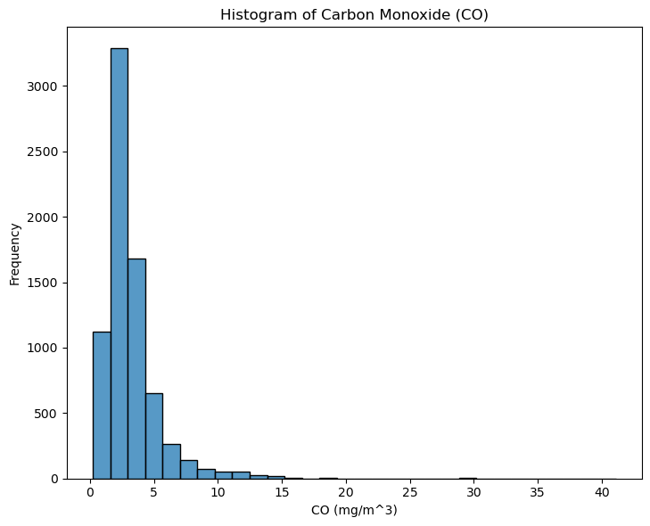

```python
# Create histograms for CO
plt.figure(figsize=(14, 6))

# Histogram for CO
plt.subplot(1, 2, 1) # 1 row, 2 columns, 1st subplot
sns.histplot(df['CO'], kde=False, bins=30)
plt.title('Histogram of Carbon Monoxide (CO)')
plt.xlabel('CO (mg/m^3)')
plt.ylabel('Frequency')
plt.tight_layout()
plt.show();
```

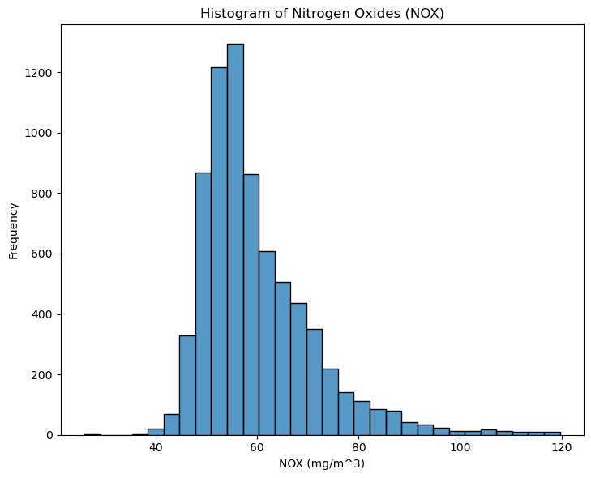

```python
# Create histograms for NOX
plt.figure(figsize=(14, 6))
# Histogram for NOX
plt.subplot(1, 2, 2) # 1 row, 2 columns, 2nd subplot
sns.histplot(df['NOX'], kde=False, bins=30)
plt.title('Histogram of Nitrogen Oxides (NOX)')
plt.xlabel('NOX (mg/m^3)')
plt.ylabel('Frequency')

# Show the plot
plt.tight_layout()
plt.show();
```

#### Create a sctter plot of CO vs NOX.

[figure not shown]

```python
plt.figure(figsize=(10, 6))
sns.scatterplot(x=df['NOX'], y=df['CO'], alpha=0.8)

plt.title('Scatter Plot of CO vs NOX')
plt.xlabel('Carbon Monoxide (CO) [mg/m^3]')
plt.ylabel('Nitrogen Oxides (NOX) [mg/m^3]')
plt.show();
```

### Prepare data for machine learning

- We will predict CO using all the other variables.
- NOX, which is another emission gas, will not be used as predictor.
- CO is a continuous variable, thus we will be doing regression.
- Many of algorithms that do classification also have regression counterparts.

```python
y = df.CO
X = df.drop(['CO', 'NOX'], axis=1)
```

```python
from sklearn.model_selection import train_test_split
X_train, X_test, y_train, y_test = train_test_split(X, y, test_size=0.10, random_state=RANDOM_STATE)
X_train, X_val, y_train, y_val = train_test_split(X_train, y_train, test_size=0.20, random_state=RANDOM_STATE)
```

```python
# Standardization of the data
from sklearn.preprocessing import StandardScaler
ss = StandardScaler()
ss.fit(X_train)
X_train = ss.transform(X_train)
X_val = ss.transform(X_val)
X_test = ss.transform(X_test)
```

```python
X_train.shape
```

```
(5316, 9)
```

```python
X_val.shape
```

```
(1329, 9)
```

```python
X_test.shape
```

```
(739, 9)
```

## Utility Functions

You can create helper functions. For example, create functions that take the score and store it in a dataframe for a specific model.

```python
def evaluate_model(model_name, model, X_train, y_train, X_val, y_val):
    model.fit(X_train, y_train)
    y_train_pred = model.predict(X_train)
    y_val_pred = model.predict(X_val)
    metrics = {
        'Model': model_name,
        'R2_Train': r2_score(y_train, y_train_pred),
        'R2_Val': r2_score(y_val, y_val_pred),
        'RMSE_Train': np.sqrt(mean_squared_error(y_train, y_train_pred)),
        'RMSE_Val': np.sqrt(mean_squared_error(y_val, y_val_pred))
    }
    return metrics
```

```python
def evaluate_model(model_name, kernel, model, X_train, y_train, X_val, y_val):
    model.fit(X_train, y_train)
    y_train_pred = model.predict(X_train)
    y_val_pred = model.predict(X_val)
    metrics = {
        'Model': model_name,
        'Kernel': kernel,
        'R2_Train': r2_score(y_train, y_train_pred),
        'R2_Val': r2_score(y_val, y_val_pred),
        'RMSE_Train': np.sqrt(mean_squared_error(y_train, y_train_pred)),
        'RMSE_Val': np.sqrt(mean_squared_error(y_val, y_val_pred))
    }
    return metrics
```

## Q2 [10]

- Apply Linear Regression. Predict CO emission using other variables.
  - What is the model $R^2$ on training data?
  - What is the $R^2$ on validation data?
  - What is the Root Mean Squared Error (RMSE) on training data?
  - What is the RMSE on validation data?
> - $R^2$ higher is better. ($R^2$ is % variation in data being explained)
> - RMSE lower is better. (RMSE (Root Mean Squared Error) is error, meaning the difference between predictions and actual data)

Hint:

- You can use the `r2_score` and `mean_squared_error` methods in `sklearn.metrics`.
- You need to take the square root of Mean Squared Error to get to RMSE. (MSE $\rightarrow$ square root $\rightarrow$ RMSE)

```python
from sklearn.linear_model import LinearRegression
```

```python
# Initialize the list to store model metrics
regressionModels = []
```

```python
linear_model = LinearRegression()
linear_model.fit(X_train, y_train)
```

```
LinearRegression()
```

```python
# Output the model's prediction on the training data
y_train_pred = linear_model.predict(X_train)

# Output the model's prediction on the validation data
y_val_pred = linear_model.predict(X_val)
```

```python
# R^2 on the training data
print("The model's R^2 on the training data is %.3f." % linear_model.score(X_train, y_train))

# R^2 on the validation data
print("The model's R^2 on the validation data is %.3f." % linear_model.score(X_val, y_val))
```

```
The model's R^2 on the training data is 0.664.
The model's R^2 on the validation data is 0.646.
```

```python
# Root Mean Squared Error (RMSE) on training data
print("\nThe model's Root Mean Squared Error (RMSE) on the training data is %.3f." % np.sqrt(metrics.mean_squared_error(y_train, y_train_pred)))

# Root Mean Squared Error (RMSE) on validation data
print("The model's Root Mean Squared Error (RMSE) on the validation data is %.3f." % np.sqrt(metrics.mean_squared_error(y_val, y_val_pred)))
```

```
The model's Root Mean Squared Error (RMSE) on the training data is 1.272.
The model's Root Mean Squared Error (RMSE) on the validation data is 1.388.
```

## Q3 [10]

- Apply Random Forest Regression with 100 trees. Predict CO emission using other variables.
  - What is the model $R^2$?
  - What is the $R^2$ on validation data?
  - What is the RMSE on training data?
  - What is the RMSE on validation data?
- Is training and validation score close? If not what might be the problem?
- If there is a large gap, try to decrease the gap by changing some hyperparameters of the Random Forest model. (In this analysis, any difference more than 0.10 $R^2$ difference can be assumed to be large.)
  - Once you reach a difference of less than or close to 0.10 between training $R^2$ and validation $R^2$ you can stop.
  - During this process your training score will probably decrease, and that is OK.

```python
from sklearn.ensemble import RandomForestRegressor
```

```python
estimator = RandomForestRegressor(n_estimators=100, random_state=RANDOM_STATE)
```

```python
def evaluate_model(model_name, model, X_train, y_train, X_val, y_val):
    model.fit(X_train, y_train)
    y_train_pred = model.predict(X_train)
    y_val_pred = model.predict(X_val)
    metrics = {
        'Model': model_name,
        'R2_Train': r2_score(y_train, y_train_pred),
        'R2_Val': r2_score(y_val, y_val_pred),
        'RMSE_Train': np.sqrt(mean_squared_error(y_train, y_train_pred)),
        'RMSE_Val': np.sqrt(mean_squared_error(y_val, y_val_pred))
    }
    return metrics
```

```python
estimator = RandomForestRegressor(n_estimators=100, random_state=RANDOM_STATE)

# Evaluate the initial model
initial_metrics = evaluate_model('Initial Random Forest', estimator, X_train, y_train, X_val, y_val)
print("Initial Model Metrics:")
for key, value in initial_metrics.items():
    if isinstance(value, str):
        print(f"{key}: {value}")
    else:
        print(f"{key}: {value:.3f}")
```

```
Initial Model Metrics:
Model: Initial Random Forest
R2_Train: 0.964
R2_Val: 0.756
RMSE_Train: 0.419
RMSE_Val: 1.154
```

```python
# Define the parameter grid for GridSearchCV
param_grid = {
    'min_samples_leaf': [1, 5, 10],
    'n_estimators': [100, 200, 300],
    'max_features': ['auto', 'sqrt', 'log2']
}
```

```python
# Perform GridSearchCV
grid_search = GridSearchCV(estimator=estimator, param_grid=param_grid, cv=10, scoring='r2', n_jobs=-3)
grid_search.fit(X_train, y_train)

# Get the best parameters and model
best_params = grid_search.best_params_
best_forest_model = grid_search.best_estimator_

# Print best parameters
print("Best Parameters from GridSearchCV:")
for param, value in best_params.items():
    print(f"{param}: {value}")
# Perform GridSearchCV
grid_search = GridSearchCV(estimator=estimator, param_grid=param_grid, cv=5, scoring='r2', n_jobs=-2)
grid_search.fit(X_train, y_train)

best_params = grid_search.best_params_
best_forest_model = grid_search.best_estimator_

print("Best Parameters from GridSearchCV:")
for param, value in best_params.items():
    print(f"{param}: {value}")
```

```
Best Parameters from GridSearchCV:
max_features: sqrt
min_samples_leaf: 5
n_estimators: 300
Best Parameters from GridSearchCV:
max_features: sqrt
min_samples_leaf: 5
n_estimators: 100
```

```python
# Evaluate the best model
best_metrics = evaluate_model('Tuned Random Forest', best_forest_model, X_train, y_train, X_val, y_val)
print("Tuned Model Metrics:")
for key, value in best_metrics.items():
    if isinstance(value, str):
        print(f"{key}: {value}")
    else:
        print(f"{key}: {value:.3f}")
```

```
Tuned Model Metrics:
Model: Tuned Random Forest
R2_Train: 0.853
R2_Val: 0.759
RMSE_Train: 0.842
RMSE_Val: 1.146
```

```python
estimator.get_params()
```

```
{'bootstrap': True,
 'ccp_alpha': 0.0,
 'criterion': 'squared_error',
 'max_depth': None,
 'max_features': 1.0,
 'max_leaf_nodes': None,
 'max_samples': None,
 'min_impurity_decrease': 0.0,
 'min_samples_leaf': 1,
 'min_samples_split': 2,
 'min_weight_fraction_leaf': 0.0,
 'n_estimators': 100,
 'n_jobs': None,
 'oob_score': False,
 'random_state': 0,
 'verbose': 0,
 'warm_start': False}
```

## Q4 [10]

- Apply Support Vector Regression. Predict CO emission using other variables.
  - What is the model $R^2$?
  - What is the $R^2$ on validation data?
  - What is the RMSE on training data?
  - What is the RMSE on validation data?
- Do this for each of the models listed below using the default parameters:
  1. **Linear kernel SVR**
  2. **Polynomial kernel SVR**
  3. **RBF kernel SVR**

```python
from sklearn.svm import SVR
```

### Linear SVM Regressor

```python
def evaluate_model(model_name, kernel, model, X_train, y_train, X_val, y_val):
    model.fit(X_train, y_train)
    y_train_pred = model.predict(X_train)
    y_val_pred = model.predict(X_val)
    metrics = {
        'Model': model_name,
        'Kernel': kernel,
        'R2_Train': r2_score(y_train, y_train_pred),
        'R2_Val': r2_score(y_val, y_val_pred),
        'RMSE_Train': np.sqrt(mean_squared_error(y_train, y_train_pred)),
        'RMSE_Val': np.sqrt(mean_squared_error(y_val, y_val_pred))
    }
    return metrics
```

```python
estimator = SVR(kernel='linear')
estimator
```

```
SVR(kernel='linear')
```

```python
linear_metrics = evaluate_model('SVR', 'linear', estimator, X_train, y_train, X_val, y_val)
```

```python
linear_metrics
```

```
{'Model': 'SVR',
 'Kernel': 'linear',
 'R2_Train': 0.6244412583337272,
 'R2_Val': 0.6021771925365862,
 'RMSE_Train': 1.3448270895923353,
 'RMSE_Val': 1.4726394044713864}
```

### Polynomial Kernel SVM Regressor

```python
from sklearn.svm import SVR
estimator = SVR(kernel='poly')
estimator
```

```
SVR(kernel='poly')
```

```python
poly_metrics = evaluate_model('SVR', 'poly', estimator, X_train, y_train, X_val, y_val)
```

```python
poly_metrics
```

```
{'Model': 'SVR',
 'Kernel': 'poly',
 'R2_Train': 0.7404852376508414,
 'R2_Val': 0.7310487212257811,
 'RMSE_Train': 1.1179143857689056,
 'RMSE_Val': 1.210844531836506}
```

### RBF Kernel SVM Regressor

```python
from sklearn.svm import SVR
estimator = SVR(kernel='rbf')
estimator
```

```
SVR()
```

```python
rbf_metrics = evaluate_model('SVR', 'rbf', estimator, X_train, y_train, X_val, y_val)
```

```python
rbf_metrics
```

```
{'Model': 'SVR',
 'Kernel': 'rbf',
 'R2_Train': 0.7653225070588423,
 'R2_Val': 0.7476173201040639,
 'RMSE_Train': 1.0630733502205554,
 'RMSE_Val': 1.1729550025939743}
```

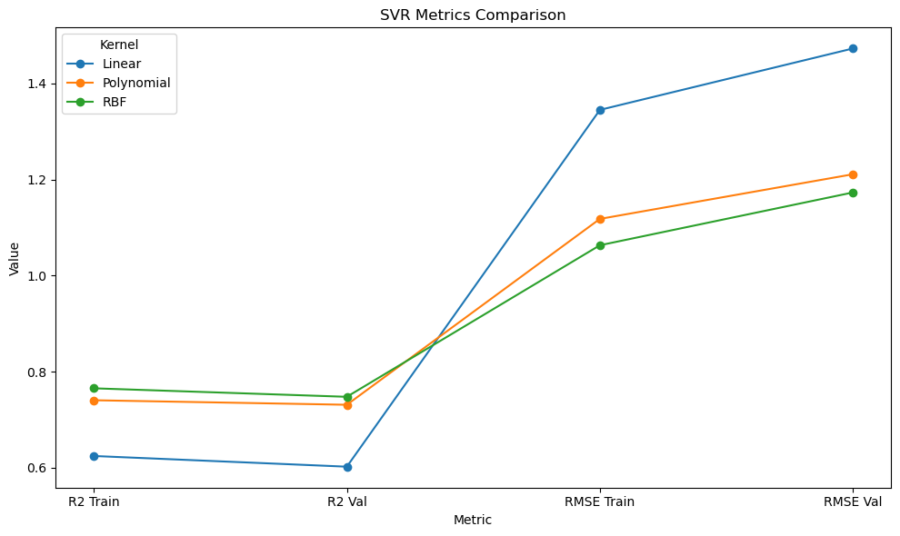

```python
metrics_data = {
    'Kernel': ['Linear', 'Polynomial', 'RBF'],
    'R2 Train': [linear_metrics['R2_Train'], poly_metrics['R2_Train'], rbf_metrics['R2_Train']],
    'R2 Val': [linear_metrics['R2_Val'], poly_metrics['R2_Val'], rbf_metrics['R2_Val']],
    'RMSE Train': [linear_metrics['RMSE_Train'], poly_metrics['RMSE_Train'], rbf_metrics['RMSE_Train']],
    'RMSE Val': [linear_metrics['RMSE_Val'], poly_metrics['RMSE_Val'], rbf_metrics['RMSE_Val']]
}


fig, ax = plt.subplots(figsize=(10, 6))

for i, kernel in enumerate(metrics_data['Kernel']):
    ax.plot(['R2 Train', 'R2 Val', 'RMSE Train', 'RMSE Val'],
            [metrics_data['R2 Train'][i], metrics_data['R2 Val'][i], metrics_data['RMSE Train'][i], metrics_data['RMSE Val'][i]],
            marker='o', linestyle='-', label=kernel)

ax.set_xlabel('Metric')
ax.set_ylabel('Value')
ax.set_title('SVR Metrics Comparison')
ax.legend(title='Kernel')
plt.tight_layout()
plt.show()
```

### Q5 [10]

- Take RBF Kernel SVM and perform hyperparameter tuning. See if you can increase the $R^2$ score.
  - Use:  
    'C': [1, 10, 100, 1000] 'gamma': [0.001, 0.01, 0.1, 1]
  - What is the model $R^2$?
  - What is the $R^2$ on validation data?
  - What is the RMSE on training data?
  - What is the RMSE on validation data?

```python
from sklearn.model_selection import GridSearchCV
```

```python
def print_results(results):
    print('BEST PARAMS: {}\n'.format(results.best_params_))
    means = results.cv_results_['mean_test_score']
    stds = results.cv_results_['std_test_score']
    for mean, std, params in zip(means, stds, results.cv_results_['params']):
        print('{:.3f} (+/-{:.2f}) for {}'.format(round(mean, 3), round(std * 2, 3), params))
```

```python
param_grid = {
    'C': [1, 10, 100, 1000],
    'gamma': [0.001, 0.01, 0.1, 1]
}
```

```python
svr_rbf = SVR(kernel='rbf')
```

```python
grid_search_rbf = GridSearchCV(estimator=svr_rbf, param_grid=param_grid, scoring='r2', cv=5, n_jobs=-1, verbose=2)
```

```python
grid_search_rbf.fit(X_train, y_train)
```

```
Fitting 5 folds for each of 16 candidates, totalling 80 fits
```

```
GridSearchCV(cv=5, estimator=SVR(), n_jobs=-1,
             param_grid={'C': [1, 10, 100, 1000],
                         'gamma': [0.001, 0.01, 0.1, 1]},
             scoring='r2', verbose=2)
```

```python
# Print the results
print_results(grid_search_rbf)
```

```
BEST PARAMS: {'C': 1000, 'gamma': 0.01}

0.616 (+/-0.14) for {'C': 1, 'gamma': 0.001}
0.759 (+/-0.13) for {'C': 1, 'gamma': 0.01}
0.771 (+/-0.15) for {'C': 1, 'gamma': 0.1}
0.717 (+/-0.18) for {'C': 1, 'gamma': 1}
0.712 (+/-0.14) for {'C': 10, 'gamma': 0.001}
0.768 (+/-0.13) for {'C': 10, 'gamma': 0.01}
0.784 (+/-0.14) for {'C': 10, 'gamma': 0.1}
0.756 (+/-0.19) for {'C': 10, 'gamma': 1}
0.764 (+/-0.12) for {'C': 100, 'gamma': 0.001}
0.775 (+/-0.13) for {'C': 100, 'gamma': 0.01}
0.784 (+/-0.14) for {'C': 100, 'gamma': 0.1}
0.720 (+/-0.18) for {'C': 100, 'gamma': 1}
0.763 (+/-0.12) for {'C': 1000, 'gamma': 0.001}
0.785 (+/-0.13) for {'C': 1000, 'gamma': 0.01}
0.772 (+/-0.13) for {'C': 1000, 'gamma': 0.1}
0.631 (+/-0.17) for {'C': 1000, 'gamma': 1}
```

```python
best_params_rbf = grid_search_rbf.best_params_
best_model_rbf = grid_search_rbf.best_estimator_
```

```python
y_train_pred_rbf = best_model_rbf.predict(X_train)
y_val_pred_rbf = best_model_rbf.predict(X_val)
```

```python
r2_train_rbf = r2_score(y_train, y_train_pred_rbf)
r2_val_rbf = r2_score(y_val, y_val_pred_rbf)
rmse_train_rbf = np.sqrt(mean_squared_error(y_train, y_train_pred_rbf))
rmse_val_rbf = np.sqrt(mean_squared_error(y_val, y_val_pred_rbf))
```

```python
print(f"Best Parameters: {best_params_rbf}")
print(f"Model R^2 (Train): {r2_train_rbf:.3f}")
print(f"R^2 (Validation): {r2_val_rbf:.3f}")
print(f"RMSE (Train): {rmse_train_rbf:.3f}")
print(f"RMSE (Validation): {rmse_val_rbf:.3f}")
```

```
Best Parameters: {'C': 1000, 'gamma': 0.01}
Model R^2 (Train): 0.792
R^2 (Validation): 0.757
RMSE (Train): 1.000
RMSE (Validation): 1.151
```

## Q6 [10]

- Apply PCA and transform the data.
  - For PCA we need to decide on the number of components. Take sufficient number of components based on variance explained
    - generally it is chosen as the number of components that can explain 90% of the variance
    - or cross-validation accuracy using an ML model.
- Use the PCA transformed data to perform regression. Use the models:
  - Linear Regression
  - Random Forest Regression (Optional to do hyper parameter tuning)
  - RBF Kernel Support Vector Regression (Optional to do hyper parameter tuning)
- For each model:
  - What is the model $R^2$?
  - What is the $R^2$ on validation data?
  - What is the RMSE on training data?
  - What is the RMSE on validation data?
- Compare these models with their counterparts obtained before. For example: Compare `PCA RBF SVR` with the `RBF SVR` model from before. Do you observe any change in performance? Please explain.

```python
from sklearn.decomposition import PCA
```

```python
pca = PCA(n_components=None)

pca.fit(X_train)
X_train_pca = pca.transform(X_train)
X_val_pca = pca.transform(X_val)
X_test_pca = pca.transform(X_test)
```

```
[0.58158952 0.78924196 0.88751722 0.94337792 0.98704348 0.9959942
 0.99975821 0.99992456 1.        ]
```

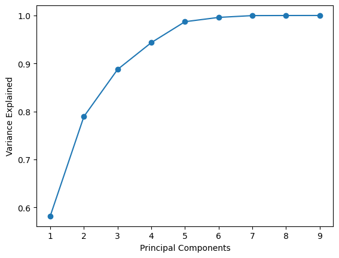

```python
print(pca.explained_variance_ratio_.cumsum())
plt.plot(pca.explained_variance_ratio_.cumsum(), '-o');
plt.xticks(ticks= range(X_train_pca.shape[1]), labels=[i+1 for i in range(X_train_pca.shape[1])])
plt.xlabel('Principal Components')
plt.ylabel('Variance Explained')
plt.show()
```

Choose the number of components.

```python
X_train_pca2 = X_train_pca[:, 0:5]
X_val_pca2 = X_val_pca[:, 0:5]
X_test_pca2 = X_test_pca[:, 0:5]
```

**Linear Regression with PCA transformed data**

```python
lr_pca_model = LinearRegression()

lr_pca_model.fit(X_train_pca2, y_train)
```

```
LinearRegression()
```

```python
# Make predictions on the PCA-transformed training and validation data
lr_train_predictions = lr_pca_model.predict(X_train_pca2)
lr_val_predictions = lr_pca_model.predict(X_val_pca2)
```

```python
# Calculate R2 and RMSE for training and validation data
lr_train_r2 = r2_score(y_train, lr_train_predictions)
lr_val_r2 = r2_score(y_val, lr_val_predictions)
lr_train_rmse = mean_squared_error(y_train, lr_train_predictions, squared=False)
lr_val_rmse = mean_squared_error(y_val, lr_val_predictions, squared=False)
```

```python
print("Linear Regression with PCA Transformed Data:")
print(f"R2 on Training Data: {lr_train_r2:.3f}")
print(f"R2 on Validation Data: {lr_val_r2:.3f}")
print(f"RMSE on Training Data: {lr_train_rmse:.3f}")
print(f"RMSE on Validation Data: {lr_val_rmse:.3f}")
```

```
Linear Regression with PCA Transformed Data:
R2 on Training Data: 0.656
R2 on Validation Data: 0.633
RMSE on Training Data: 1.287
RMSE on Validation Data: 1.414
```

**RF Regression with PCA transformed data**

```python
rf_pca_model = RandomForestRegressor(n_estimators=100, random_state=RANDOM_STATE)

# Fit the model with PCA-transformed training data
rf_pca_model.fit(X_train_pca2, y_train)
```

```
RandomForestRegressor(random_state=0)
```

```python
# Make predictions on the PCA-transformed training and validation data
rf_train_predictions = rf_pca_model.predict(X_train_pca2)
rf_val_predictions = rf_pca_model.predict(X_val_pca2)
```

```python
# Calculate R2 and RMSE for training and validation data
rf_train_r2 = r2_score(y_train, rf_train_predictions)
rf_val_r2 = r2_score(y_val, rf_val_predictions)
rf_train_rmse = mean_squared_error(y_train, rf_train_predictions, squared=False)
rf_val_rmse = mean_squared_error(y_val, rf_val_predictions, squared=False)
```

```python
print("Random Forest Regression with PCA Transformed Data:")
print(f"R2 on Training Data: {rf_train_r2:.3f}")
print(f"R2 on Validation Data: {rf_val_r2:.3f}")
print(f"RMSE on Training Data: {rf_train_rmse:.3f}")
print(f"RMSE on Validation Data: {rf_val_rmse:.3f}")
```

```
Random Forest Regression with PCA Transformed Data:
R2 on Training Data: 0.963
R2 on Validation Data: 0.737
RMSE on Training Data: 0.422
RMSE on Validation Data: 1.197
```

### Hyperaparameters tuning

```python
param_grid_rf_updated = {
    'n_estimators': [100, 200, 300, 400],
    'max_depth': [None, 10, 20, 30],
    'min_samples_split': [2, 5, 10, 15],
    'min_samples_leaf': [1, 2, 4, 6]
}

# Initialize the GridSearchCV object with updated parameters
grid_search_rf_updated = GridSearchCV(estimator=RandomForestRegressor(random_state=42),
                                      param_grid=param_grid_rf_updated,
                                      cv=5,
                                      scoring='r2',
                                      n_jobs=-1,
                                      verbose=2)
```

```python
# Fit the model with PCA-transformed training data
grid_search_rf_updated.fit(X_train_pca2, y_train)

# Best parameters and model from updated grid search
best_params_rf_updated = grid_search_rf_updated.best_params_
best_rf_model_updated = grid_search_rf_updated.best_estimator_
```

```
Fitting 5 folds for each of 256 candidates, totalling 1280 fits
```

```python
# Predictions with updated model
best_rf_train_predictions_updated = best_rf_model_updated.predict(X_train_pca2)
best_rf_val_predictions_updated = best_rf_model_updated.predict(X_val_pca2)

# Calculate R2 and RMSE for training and validation data with updated model
best_rf_train_r2_updated = r2_score(y_train, best_rf_train_predictions_updated)
best_rf_val_r2_updated = r2_score(y_val, best_rf_val_predictions_updated)
best_rf_train_rmse_updated = mean_squared_error(y_train, best_rf_train_predictions_updated, squared=False)
best_rf_val_rmse_updated = mean_squared_error(y_val, best_rf_val_predictions_updated, squared=False)
```

```python
print("Updated Random Forest Regression with PCA Transformed Data and GridSearchCV:")
print(f"Best Parameters: {best_params_rf_updated}")
print(f"R2 on Training Data: {best_rf_train_r2_updated:.3f}")
print(f"R2 on Validation Data: {best_rf_val_r2_updated:.3f}")
print(f"RMSE on Training Data: {best_rf_train_rmse_updated:.3f}")
print(f"RMSE on Validation Data: {best_rf_val_rmse_updated:.3f}")
```

```
Updated Random Forest Regression with PCA Transformed Data and GridSearchCV:
Best Parameters: {'max_depth': 20, 'min_samples_leaf': 4, 'min_samples_split': 2, 'n_estimators': 400}
R2 on Training Data: 0.861
R2 on Validation Data: 0.749
RMSE on Training Data: 0.819
RMSE on Validation Data: 1.171
```

**SVM Regression with PCA transformed data**

```python
svm_pca_model = SVR(kernel='rbf')

svm_pca_model.fit(X_train_pca2, y_train)
```

```
SVR()
```

```python
# Make predictions on the PCA-transformed training and validation data
svm_train_predictions = svm_pca_model.predict(X_train_pca2)
svm_val_predictions = svm_pca_model.predict(X_val_pca2)
```

```python
# Calculate R2 and RMSE for training and validation data
svm_train_r2 = r2_score(y_train, svm_train_predictions)
svm_val_r2 = r2_score(y_val, svm_val_predictions)
svm_train_rmse = mean_squared_error(y_train, svm_train_predictions, squared=False)
svm_val_rmse = mean_squared_error(y_val, svm_val_predictions, squared=False)
```

```python
print("SVM Regression with PCA Transformed Data:")
print(f"R2 on Training Data: {svm_train_r2:.3f}")
print(f"R2 on Validation Data: {svm_val_r2:.3f}")
print(f"RMSE on Training Data: {svm_train_rmse:.3f}")
print(f"RMSE on Validation Data: {svm_val_rmse:.3f}")
```

```
SVM Regression with PCA Transformed Data:
R2 on Training Data: 0.760
R2 on Validation Data: 0.747
RMSE on Training Data: 1.075
RMSE on Validation Data: 1.175
```

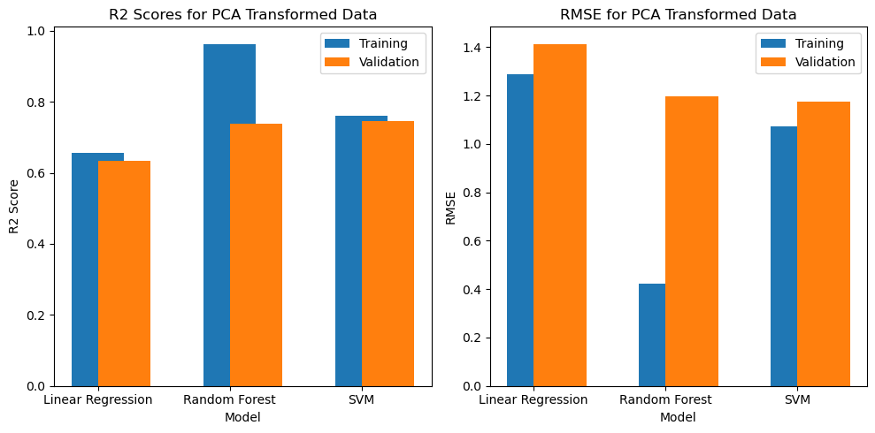

```python
models = ['Linear Regression', 'Random Forest', 'SVM']
r2_train = [lr_train_r2, rf_train_r2, svm_train_r2]
r2_val = [lr_val_r2, rf_val_r2, svm_val_r2]
rmse_train = [lr_train_rmse, rf_train_rmse, svm_train_rmse]
rmse_val = [lr_val_rmse, rf_val_rmse, svm_val_rmse]

plt.figure(figsize=(10, 5))
plt.subplot(1, 2, 1)
plt.bar(models, r2_train, width=0.4, label='Training', align='center')
plt.bar(models, r2_val, width=0.4, label='Validation', align='edge')
plt.xlabel('Model')
plt.ylabel('R2 Score')
plt.title('R2 Scores for PCA Transformed Data')
plt.legend()

plt.subplot(1, 2, 2)
plt.bar(models, rmse_train, width=0.4, label='Training', align='center')
plt.bar(models, rmse_val, width=0.4, label='Validation', align='edge')
plt.xlabel('Model')
plt.ylabel('RMSE')
plt.title('RMSE for PCA Transformed Data')
plt.legend()

plt.tight_layout()
plt.show()
```

### Observation and comaparison

1. Linear Regression shows a moderate fit with a slight drop in performance from training to validation data, indicating a small level of overfitting.
2. Random Forest Regression shows a high level of fit on the training data but a significant drop in performance on the validation data, indicating a higher level of overfitting compared to Linear Regression.
3. SVM Regression with the RBF kernel shows a good balance between training and validation performance, with less overfitting compared to Random Forest Regression.

   SVM Regression with PCA-transformed data appears to provide the best balance between training and validation performance, with relatively less overfitting compared to Random Forest Regression. Linear Regression, while showing less overfitting, has lower R2 scores, indicating a less accurate fit. Random Forest Regression, despite its high R2 score on training data, shows a significant drop in performance on validation data, indicating overfitting.

## Q7 [10]

#### Let's do classification

We will convert CO target values into binary form by comparing them to a threshold. $ 0 - 3 mg/m^3$ is the range of max 8-hour avg. ambient CO in most US cities. So let's take that.  
[CO Levels of Concern in Government Recommendations and Regulations](https://www.carbonmonoxidekills.com/are-you-at-risk/carbon-monoxide-levels/)

```python
from sklearn.preprocessing import Binarizer
```

```python
binarizer = Binarizer(threshold=3)
```

```python
y_train_cat = binarizer.transform(y_train.values.reshape(-1,1)).ravel()
y_val_cat = binarizer.transform(y_val.values.reshape(-1,1)).ravel()
y_test_cat = binarizer.transform(y_test.values.reshape(-1,1)).ravel()
```

```python
y_train_cat = pd.Series(y_train_cat)
```

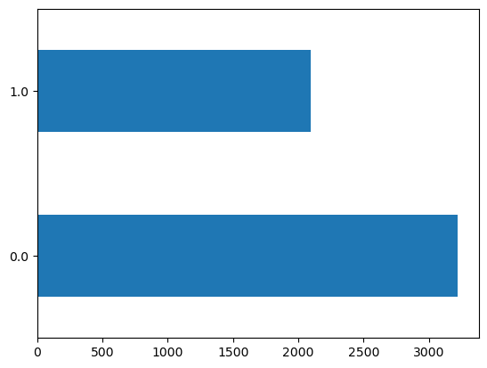

```python
y_train_cat.value_counts().plot.barh()
```

### Fit RBF Kernel SVM Classifier

#### 1. Standardized training data

- Using the standardized training data perform grid search:
  - Find the best combination of the `C` and `gamma` hyper-parameters.
- For the best model:
  - Either using the confusion matrix or the methods in `sklearn.metrics` get the following metrics on the validation set:
  - Create confusion matrix
  - Recall (Sensitivity)
  - Specificity
  - Precision
  - Balanced Accuracy
  - F1 Score

#### 2. PCA transformed training data

- Using the **pca** transformed training data `X_train_pca2` perform grid search:
  - Find the best combination of the `C` and `gamma` hyper-parameters.
- For the best model:
  - Either using the confusion matrix or the methods in `sklearn.metrics` get the following metrics on the validation set `X_val_pca2`:
    - Create confusion matrix
    - Recall (Sensitivity)
    - Specificity
    - Precision
    - Balanced Accuracy
    - F1 Score

```python
from sklearn.svm import SVC
```

```python
estimator = SVC(kernel ='rbf')
```

#### SVC Model 1

```python
# Standardize the features
scaler_std = StandardScaler()
X_train_std = scaler_std.fit_transform(X_train)
X_val_std = scaler_std.transform(X_val)
X_test_std = scaler_std.transform(X_test)

# Define the parameter grid for the SVM classifier
param_grid_svm = {
    'C': [1, 10, 100, 1000],
    'gamma': [0.001, 0.01, 0.1, 1]
}

# Initialize the GridSearchCV object for the SVM classifier
grid_search_svm = GridSearchCV(estimator=SVC(kernel='rbf'),
                               param_grid=param_grid_svm,
                               cv=5,
                               scoring='accuracy',
                               n_jobs=-1,
                               verbose=2)

# Fit the model with standardized training data
grid_search_svm.fit(X_train_std, y_train_cat)

# Best parameters and model
best_params_svm = grid_search_svm.best_params_
best_svm_model = grid_search_svm.best_estimator_

# Accuracy on training and validation data
accuracy_train_svm = accuracy_score(y_train_cat, best_svm_model.predict(X_train_std))
accuracy_val_svm = accuracy_score(y_val_cat, best_svm_model.predict(X_val_std))

# Predictions and evaluation metrics for the validation set
svm_val_predictions = best_svm_model.predict(X_val_std)
svm_conf_matrix = confusion_matrix(y_val_cat, svm_val_predictions)
svm_recall = recall_score(y_val_cat, svm_val_predictions)
svm_specificity = recall_score(y_val_cat, svm_val_predictions, pos_label=0)
svm_precision = precision_score(y_val_cat, svm_val_predictions)
svm_balanced_accuracy = balanced_accuracy_score(y_val_cat, svm_val_predictions)
svm_f1_score = f1_score(y_val_cat, svm_val_predictions)

# Display results
print(f"The model's accuracy on training is: {accuracy_train_svm:.2f}")
print(f"The model's accuracy on validation is: {accuracy_val_svm:.2f}")
print("\nThe Confusion Matrix is given below:")
print(svm_conf_matrix)
print("\nThe classification report is given below:")
print(classification_report(y_val_cat, svm_val_predictions))
print(f"Recall (Sensitivity): {svm_recall:.2f}")
print(f"Specificity: {svm_specificity:.2f}")
print(f"Precision: {svm_precision:.2f}")
print(f"Balanced Accuracy: {svm_balanced_accuracy:.2f}")
print(f"F1 Score: {svm_f1_score:.2f}")
```

```
Fitting 5 folds for each of 16 candidates, totalling 80 fits
The model's accuracy on training is: 0.94
The model's accuracy on validation is: 0.91

The Confusion Matrix is given below:
[[762  50]
 [ 68 449]]

The classification report is given below:
              precision    recall  f1-score   support

         0.0       0.92      0.94      0.93       812
         1.0       0.90      0.87      0.88       517

    accuracy                           0.91      1329
   macro avg       0.91      0.90      0.91      1329
weighted avg       0.91      0.91      0.91      1329

Recall (Sensitivity): 0.87
Specificity: 0.94
Precision: 0.90
Balanced Accuracy: 0.90
F1 Score: 0.88
```

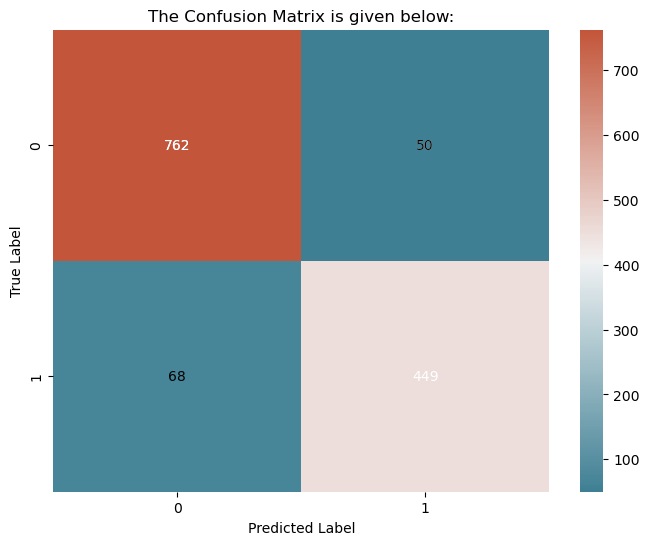

```python
svm_conf_matrix = confusion_matrix(y_val_cat, svm_val_predictions)

# Plotting the confusion matrix
fig, ax = plt.subplots(figsize=(8, 6))
cmap = sns.diverging_palette(220, 20, as_cmap=True)
sns.heatmap(svm_conf_matrix, annot=True, fmt="d", cmap=cmap, ax=ax)

# Adding text annotations
for i in range(svm_conf_matrix.shape[0]):
    for j in range(svm_conf_matrix.shape[1]):
        color = "white" if svm_conf_matrix[i, j] > svm_conf_matrix.max() / 2 else "black"
        ax.text(j + 0.5, i + 0.5, svm_conf_matrix[i, j],
                horizontalalignment='center',
                verticalalignment='center',
                color=color)

# Setting labels and title
ax.set_title('The Confusion Matrix is given below:')
ax.set_ylabel('True Label')
ax.set_xlabel('Predicted Label')
plt.show()
```

#### SVC Model 2

```python
# Apply PCA to the training and validation data
pca_transformer = PCA(n_components=0.90)  # Retain 90% of variance
X_train_pca_transformed = pca_transformer.fit_transform(X_train_std)
X_val_pca_transformed = pca_transformer.transform(X_val_std)

# Define the parameter grid for the SVM classifier
svm_params_grid = {
    'C': [1, 10, 100, 1000],
    'gamma': [0.001, 0.01, 0.1, 1]
}

# Initialize the GridSearchCV object for the SVM classifier
svm_pca_grid_search = GridSearchCV(estimator=SVC(kernel='rbf'),
                                   param_grid=svm_params_grid,
                                   cv=5,
                                   scoring='accuracy',
                                   n_jobs=-1,
                                   verbose=2)

# Fit the model with PCA-transformed training data and print the fitting process
svm_pca_grid_search.fit(X_train_pca_transformed, y_train_cat)

# Best parameters and model
best_svm_pca_params = svm_pca_grid_search.best_params_
best_svm_pca_model = svm_pca_grid_search.best_estimator_

# Accuracy on training and validation data
accuracy_train_pca = accuracy_score(y_train_cat, best_svm_pca_model.predict(X_train_pca_transformed))
accuracy_val_pca = accuracy_score(y_val_cat, best_svm_pca_model.predict(X_val_pca_transformed))

# Predictions and evaluation metrics for the validation set
pca_svm_val_predictions = best_svm_pca_model.predict(X_val_pca_transformed)
pca_svm_conf_matrix = confusion_matrix(y_val_cat, pca_svm_val_predictions)

# Display results
print(f"The model's accuracy on training is: {accuracy_train_pca:.2f}")
print(f"The model's accuracy on validation is: {accuracy_val_pca:.2f}")
print("\nThe Confusion Matrix is given below:")
print(pca_svm_conf_matrix)
print("\nThe classification report is given below:")
print(classification_report(y_val_cat, pca_svm_val_predictions))

# Additional metrics
pca_svm_recall = recall_score(y_val_cat, pca_svm_val_predictions)
pca_svm_specificity = recall_score(y_val_cat, pca_svm_val_predictions, pos_label=0)
pca_svm_precision = precision_score(y_val_cat, pca_svm_val_predictions)
pca_svm_bal_accuracy = (pca_svm_recall + pca_svm_specificity) / 2
pca_svm_f1 = f1_score(y_val_cat, pca_svm_val_predictions)

print(f"Recall (Sensitivity): {pca_svm_recall:.2f}")
print(f"Specificity: {pca_svm_specificity:.2f}")
print(f"Precision: {pca_svm_precision:.2f}")
print(f"Balanced Accuracy: {pca_svm_bal_accuracy:.2f}")
print(f"F1 Score: {pca_svm_f1:.2f}")
```

```
Fitting 5 folds for each of 16 candidates, totalling 80 fits
The model's accuracy on training is: 0.93
The model's accuracy on validation is: 0.91

The Confusion Matrix is given below:
[[764  48]
 [ 70 447]]

The classification report is given below:
              precision    recall  f1-score   support

         0.0       0.92      0.94      0.93       812
         1.0       0.90      0.86      0.88       517

    accuracy                           0.91      1329
   macro avg       0.91      0.90      0.91      1329
weighted avg       0.91      0.91      0.91      1329

Recall (Sensitivity): 0.86
Specificity: 0.94
Precision: 0.90
Balanced Accuracy: 0.90
F1 Score: 0.88
```

## Q8 [10]

- For regression:
  - Think of other ways of improving the regression performance and list at least two possibilities.
  - You can use any of the datasets we have been using (standardized data, PCA transformed data), or re-create your own set from the original.
  - Implement both of the methods you proposed.
  - Is the validation performance increasing? For performance comparison you can use any regression performance metric that you deem to be appropriate.
  - Optional: Apply different methods, ideas as you see fit and see if the validation performance is improving.

```python
from sklearn.linear_model import LinearRegression
from sklearn.metrics import r2_score, classification_report, accuracy_score
from sklearn.svm import SVC

from sklearn.metrics import confusion_matrix
from sklearn.metrics import recall_score, precision_score, f1_score, balanced_accuracy_score

def calculate_metrics(y_true, y_pred):
    recall = recall_score(y_true, y_pred)
    specificity = recall_score(y_true, y_pred, pos_label=0)
    precision = precision_score(y_true, y_pred)
    balanced_accuracy = balanced_accuracy_score(y_true, y_pred)
    f1 = f1_score(y_true, y_pred)
    return recall, specificity, precision, balanced_accuracy, f1

# Standard Linear Regression
lr = LinearRegression()
lr.fit(X_train, y_train)
y_val_pred_lr = lr.predict(X_val)
r2_lr = r2_score(y_val, y_val_pred_lr)
```

```python
# Linear Regression with PCA
pca = PCA(n_components=0.95)
X_train_pca = pca.fit_transform(X_train)
X_val_pca = pca.transform(X_val)
lr_pca = LinearRegression()
lr_pca.fit(X_train_pca, y_train)
y_val_pred_pca = lr_pca.predict(X_val_pca)
r2_pca = r2_score(y_val, y_val_pred_pca)
```

```python
# Polynomial Regression
poly = PolynomialFeatures(degree=2)
X_train_poly = poly.fit_transform(X_train)
X_val_poly = poly.transform(X_val)
lr_poly = LinearRegression()
lr_poly.fit(X_train_poly, y_train)
y_val_pred_poly = lr_poly.predict(X_val_poly)
r2_poly = r2_score(y_val, y_val_pred_poly)
```

```python
# Classification Report
# Binarize the continuous output for classification report
threshold = np.median(y_val)
y_val_class = (y_val > threshold).astype(int)
y_val_pred_lr_class = (y_val_pred_lr > threshold).astype(int)
y_val_pred_pca_class = (y_val_pred_pca > threshold).astype(int)
y_val_pred_poly_class = (y_val_pred_poly > threshold).astype(int)

print("Linear Regression Classification Report:")
print(classification_report(y_val_class, y_val_pred_lr_class))

print("Linear Regression with PCA Classification Report:")
print(classification_report(y_val_class, y_val_pred_pca_class))

print("Polynomial Regression Classification Report:")
print(classification_report(y_val_class, y_val_pred_poly_class))
```

```
Linear Regression Classification Report:
              precision    recall  f1-score   support

           0       0.87      0.70      0.78       665
           1       0.75      0.89      0.82       664

    accuracy                           0.80      1329
   macro avg       0.81      0.80      0.80      1329
weighted avg       0.81      0.80      0.80      1329

Linear Regression with PCA Classification Report:
              precision    recall  f1-score   support

           0       0.86      0.72      0.78       665
           1       0.76      0.88      0.82       664

    accuracy                           0.80      1329
   macro avg       0.81      0.80      0.80      1329
weighted avg       0.81      0.80      0.80      1329

Polynomial Regression Classification Report:
              precision    recall  f1-score   support

           0       0.88      0.89      0.88       665
           1       0.89      0.88      0.88       664

    accuracy                           0.88      1329
   macro avg       0.88      0.88      0.88      1329
weighted avg       0.88      0.88      0.88      1329
```

```python
# Comparison
print("\nValidation Performance Comparison:")
print(f"Standard Linear Regression R2 Score: {r2_lr:.3f}")
print(f"Linear Regression with PCA R2 Score: {r2_pca:.3f}")
print(f"Polynomial Regression R2 Score: {r2_poly:.3f}")
```

```
Validation Performance Comparison:
Standard Linear Regression R2 Score: 0.646
Linear Regression with PCA R2 Score: 0.633
Polynomial Regression R2 Score: 0.740
```

```python
from sklearn.preprocessing import Binarizer
from sklearn.linear_model import LinearRegression
from sklearn.decomposition import PCA
from sklearn.preprocessing import PolynomialFeatures
from sklearn.metrics import r2_score, classification_report, confusion_matrix
import numpy as np

# Fit Linear Regression
model_lr = LinearRegression()
model_lr.fit(X_train, y_train)
y_val_pred_lr = model_lr.predict(X_val)
```

```python
# Fit Linear Regression with PCA
pca = PCA(n_components=5)
X_train_pca = pca.fit_transform(X_train)
X_val_pca = pca.transform(X_val)
model_lr_pca = LinearRegression()
model_lr_pca.fit(X_train_pca, y_train)
y_val_pred_pca = model_lr_pca.predict(X_val_pca)
```

```python
# Fit Polynomial Regression
poly = PolynomialFeatures(degree=2)
X_train_poly = poly.fit_transform(X_train)
X_val_poly = poly.transform(X_val)
model_poly = LinearRegression()
model_poly.fit(X_train_poly, y_train)
y_val_pred_poly = model_poly.predict(X_val_poly)
```

```python
# R2 scores
r2_lr = r2_score(y_val, y_val_pred_lr)
r2_pca = r2_score(y_val, y_val_pred_pca)
r2_poly = r2_score(y_val, y_val_pred_poly)
```

```python
# Binarize the continuous output for classification report
binarizer = Binarizer(threshold=np.median(y_val))
y_val_class = binarizer.transform(y_val.to_numpy().reshape(-1, 1)).ravel()
y_val_pred_lr_class = binarizer.transform(y_val_pred_lr.reshape(-1, 1)).ravel()
y_val_pred_pca_class = binarizer.transform(y_val_pred_pca.reshape(-1, 1)).ravel()
y_val_pred_poly_class = binarizer.transform(y_val_pred_poly.reshape(-1, 1)).ravel()
```

```python
# Classification reports
print("Classification Report for Linear Regression:")
print(classification_report(y_val_class, y_val_pred_lr_class))

print("Classification Report for Linear Regression with PCA:")
print(classification_report(y_val_class, y_val_pred_pca_class))

print("Classification Report for Polynomial Regression:")
print(classification_report(y_val_class, y_val_pred_poly_class))
```

```
Classification Report for Linear Regression:
              precision    recall  f1-score   support

         0.0       0.87      0.70      0.78       665
         1.0       0.75      0.89      0.82       664

    accuracy                           0.80      1329
   macro avg       0.81      0.80      0.80      1329
weighted avg       0.81      0.80      0.80      1329

Classification Report for Linear Regression with PCA:
              precision    recall  f1-score   support

         0.0       0.86      0.72      0.78       665
         1.0       0.76      0.88      0.82       664

    accuracy                           0.80      1329
   macro avg       0.81      0.80      0.80      1329
weighted avg       0.81      0.80      0.80      1329

Classification Report for Polynomial Regression:
              precision    recall  f1-score   support

         0.0       0.88      0.89      0.88       665
         1.0       0.89      0.88      0.88       664

    accuracy                           0.88      1329
   macro avg       0.88      0.88      0.88      1329
weighted avg       0.88      0.88      0.88      1329
```

## Q9 [10]

- For classification:
  - Try at least one classifier other than SVM (RF, GBM, Logistic Regression, etc).
  - Think of other ways of improving the regression performance and list at least two possibilities.
  - You can use any of the datasets we have been using (standardized data, PCA transformed data), or re-create your own set from the original.
  - Implement both of the methods you proposed.
  - Is the validation performance increasing? For performance comparison you can use any regression performance metric that you deem to be appropriate.
  - Optional: Apply different methods, ideas as you see fit and see if the validation performance is improving.

```python
# Convert CO target values into binary form using a threshold
threshold = 3
binarizer = Binarizer(threshold=threshold)

y_train_bin = binarizer.fit_transform(y_train.values.reshape(-1, 1)).ravel()
y_val_bin = binarizer.transform(y_val.values.reshape(-1, 1)).ravel()
# Gradient Boosting Machine Classifier
gbm = GradientBoostingClassifier(random_state=RANDOM_STATE)
gbm.fit(X_train, y_train_bin)
```

```
GradientBoostingClassifier(random_state=0)
```

```python
# Feature Selection for GBM
selector_gbm = SelectFromModel(gbm, prefit=True)
X_train_selected_gbm = selector_gbm.transform(X_train)
X_val_selected_gbm = selector_gbm.transform(X_val)

gbm_selected = GradientBoostingClassifier(random_state=RANDOM_STATE)
gbm_selected.fit(X_train_selected_gbm, y_train_bin)
y_val_pred_selected_gbm = gbm_selected.predict(X_val_selected_gbm)
```

```python
# Hyperparameter Tuning for GBM
param_grid_gbm = {
    'n_estimators': [100, 200, 300],
    'learning_rate': [0.01, 0.1, 0.2],
    'max_depth': [3, 4, 5],
    'min_samples_split': [2, 5, 10],
    'min_samples_leaf': [1, 2, 4],
}
grid_search_gbm = GridSearchCV(gbm, param_grid_gbm, cv=5, scoring='accuracy', n_jobs=-1)
grid_search_gbm.fit(X_train, y_train_bin)
best_gbm = grid_search_gbm.best_estimator_
y_val_pred_best_gbm = best_gbm.predict(X_val)
```

```python
# Performance Metrics for GBM
accuracy_selected_gbm = accuracy_score(y_val_bin, y_val_pred_selected_gbm)
accuracy_best_gbm = accuracy_score(y_val_bin, y_val_pred_best_gbm)

print(f"GBM Accuracy with feature selection: {accuracy_selected_gbm:.3f}")
print(f"GBM Accuracy with hyperparameter tuning: {accuracy_best_gbm:.3f}")
```

```
GBM Accuracy with feature selection: 0.875
GBM Accuracy with hyperparameter tuning: 0.916
```

```
GBM with Feature Selection:
              precision    recall  f1-score   support

         0.0       0.88      0.92      0.90       812
         1.0       0.86      0.81      0.83       517

    accuracy                           0.88      1329
   macro avg       0.87      0.86      0.87      1329
weighted avg       0.87      0.88      0.87      1329
```

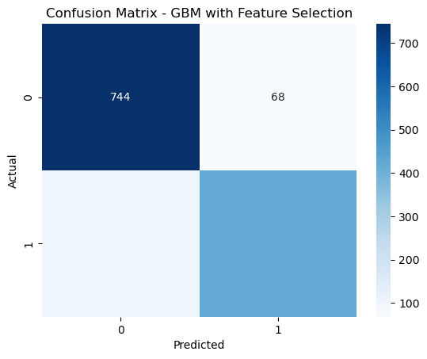

```python
# Classification Report and Confusion Matrix for GBM with Feature Selection
print("GBM with Feature Selection:")
print(classification_report(y_val_bin, y_val_pred_selected_gbm))
conf_matrix_selected_gbm = confusion_matrix(y_val_bin, y_val_pred_selected_gbm)
sns.heatmap(conf_matrix_selected_gbm, annot=True, fmt="d", cmap="Blues")
plt.title("Confusion Matrix - GBM with Feature Selection")
plt.xlabel("Predicted")
plt.ylabel("Actual")
plt.show()
```

```
GBM with Hyperparameter Tuning:
              precision    recall  f1-score   support

         0.0       0.92      0.95      0.93       812
         1.0       0.92      0.86      0.89       517

    accuracy                           0.92      1329
   macro avg       0.92      0.91      0.91      1329
weighted avg       0.92      0.92      0.92      1329
```

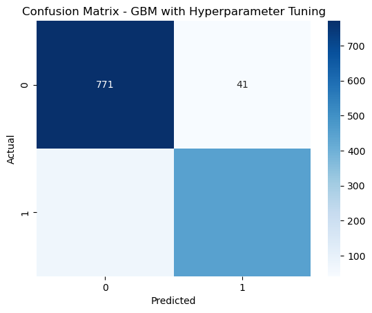

```python
# Classification Report and Confusion Matrix for GBM with Hyperparameter Tuning
print("GBM with Hyperparameter Tuning:")
print(classification_report(y_val_bin, y_val_pred_best_gbm))
conf_matrix_best_gbm = confusion_matrix(y_val_bin, y_val_pred_best_gbm)
sns.heatmap(conf_matrix_best_gbm, annot=True, fmt="d", cmap="Blues")
plt.title("Confusion Matrix - GBM with Hyperparameter Tuning")
plt.xlabel("Predicted")
plt.ylabel("Actual")
plt.show()
```

## Q10 [10]

- Choose the best 2 regressors among the trained regressions models:
- Create a table summarizing results on the **test** set for regression (with target variables in `y_test`):
  - Show the R^2 and RMSE performance metrics on test data for each model.
- Which model is best for regression? Is this in line with your analysis (the validation performance of the models) or is this not expected?
- Choose the best 2 classifiers among the trained classification models:
- Create a table summarizing results on the **test** set for classification (with target variables in `y_test_cat`):
  - Show the classification performance metrics (accuracy, recall, precision, f1-score, etc.) on test data for each model.
- Which model is best for classification? Is this in line with your analysis (the validation performance of the models) or is this not expected?

> Note that the same transformation used during training should be applied on the testing set. (If you applied PCA on training data for the selected model, you need to apply PCA on the testing set as well.)

```python
# Prepare the data for machine learning
y = df.CO
X = df.drop(['CO', 'NOX'], axis=1)
X_train, X_test, y_train, y_test = train_test_split(X, y, test_size=0.10, random_state=42)
X_train, X_val, y_train, y_val = train_test_split(X_train, y_train, test_size=0.20, random_state=42)
```

```python
# Standardize the data
scaler = StandardScaler()
X_train = scaler.fit_transform(X_train)
X_val = scaler.transform(X_val)
X_test = scaler.transform(X_test)
```

```python
# Define a function to evaluate models
def evaluate_model(model, X_train, y_train, X_val, y_val):
    model.fit(X_train, y_train)
    y_train_pred = model.predict(X_train)
    y_val_pred = model.predict(X_val)
    return {
        'R2_Train': r2_score(y_train, y_train_pred),
        'R2_Val': r2_score(y_val, y_val_pred),
        'RMSE_Train': np.sqrt(mean_squared_error(y_train, y_train_pred)),
        'RMSE_Val': np.sqrt(mean_squared_error(y_val, y_val_pred))
    }
```

```python
# Train and evaluate models
models = {
    'Linear Regression': LinearRegression(),
    'Random Forest': RandomForestRegressor(n_estimators=100, random_state=42),
    'SVR (Linear Kernel)': SVR(kernel='linear'),
    'SVR (Polynomial Kernel)': SVR(kernel='poly'),
    'SVR (RBF Kernel)': SVR(kernel='rbf')
}

results = []
for name, model in models.items():
    metrics = evaluate_model(model, X_train, y_train, X_val, y_val)
    results.append({
        'Model': name,
        **metrics
    })
```

```python
# Convert results to DataFrame
df_results = pd.DataFrame(results)

# Display the results
df_results
```

|  | Model | R2_Train | R2_Val | RMSE_Train | RMSE_Val |
| --- | --- | --- | --- | --- | --- |
| 0 | Linear Regression | 0.631913 | 0.766869 | 1.353252 | 0.983789 |
| 1 | Random Forest | 0.960552 | 0.850410 | 0.443015 | 0.788050 |
| 2 | SVR (Linear Kernel) | 0.596125 | 0.719723 | 1.417513 | 1.078688 |
| 3 | SVR (Polynomial Kernel) | 0.702983 | 0.855636 | 1.215608 | 0.774160 |
| 4 | SVR (RBF Kernel) | 0.737675 | 0.896187 | 1.142412 | 0.656488 |

```python
binarizer = Binarizer(threshold=3)  # Adjust the threshold as needed
y_train_bin = binarizer.fit_transform(y_train.values.reshape(-1, 1)).ravel()
y_val_bin = binarizer.transform(y_val.values.reshape(-1, 1)).ravel()
y_test_bin = binarizer.transform(y_test.values.reshape(-1, 1)).ravel()
```

```python
#  To evaluate classification models
def evaluate_classification_model(model, X_train, y_train_bin, X_val, y_val_bin):
    model.fit(X_train, y_train_bin)
    y_val_pred = model.predict(X_val)
    return {
        'Accuracy': accuracy_score(y_val_bin, y_val_pred),
        'Recall': recall_score(y_val_bin, y_val_pred),
        'Precision': precision_score(y_val_bin, y_val_pred),
        'F1 Score': f1_score(y_val_bin, y_val_pred)
    }
```

```python
# Train and evaluate classification models
classification_models = {
    'Random Forest Classifier': RandomForestClassifier(n_estimators=100, random_state=42),
    'SVM Classifier (RBF Kernel)': SVC(kernel='rbf')
}

classification_results = []
for name, model in classification_models.items():
    metrics = evaluate_classification_model(model, X_train, y_train_bin, X_val, y_val_bin)
    classification_results.append({
        'Model': name,
        **metrics
    })
```

```python
# Convert classification results to DataFrame
df_classification_results = pd.DataFrame(classification_results)

# Display the classification results
df_classification_results
```

|  | Model | Accuracy | Recall | Precision | F1 Score |
| --- | --- | --- | --- | --- | --- |
| 0 | Random Forest Classifier | 0.925508 | 0.892727 | 0.924670 | 0.908418 |
| 1 | SVM Classifier (RBF Kernel) | 0.914974 | 0.870909 | 0.919386 | 0.894491 |

```python
# To evaluate classification models on the test set
def evaluate_classification_model_test(model, X_test, y_test_bin):
    y_test_pred = model.predict(X_test)
    return {
        'Accuracy': accuracy_score(y_test_bin, y_test_pred),
        'Recall': recall_score(y_test_bin, y_test_pred),
        'Precision': precision_score(y_test_bin, y_test_pred),
        'F1 Score': f1_score(y_test_bin, y_test_pred)
    }
```

```python
# Evaluate the models on the test set
test_classification_results = []
for name, model in classification_models.items():
    metrics = evaluate_classification_model_test(model, X_test, y_test_bin)
    test_classification_results.append({
        'Model': name,
        **metrics
    })
```

```python
# Convert test classification results to DataFrame
df_test_classification_results = pd.DataFrame(test_classification_results)

# Display the test classification results
df_test_classification_results
```

|  | Model | Accuracy | Recall | Precision | F1 Score |
| --- | --- | --- | --- | --- | --- |
| 0 | Random Forest Classifier | 0.922869 | 0.868687 | 0.934783 | 0.900524 |
| 1 | SVM Classifier (RBF Kernel) | 0.913396 | 0.872054 | 0.908772 | 0.890034 |

- What did you learn in this project? Any suggestions?

# Thank you

Ilyas Ustun  
twitter: _ilyas_ustun_